# Introduction to Probability

We colloquially use the term **probabilithy** to mean the chances that some event occurs. We will strive to make this notion concrete and rigorous so that we can compute probabilities.

# Experiments, Sample Space, and Events

An **experiment** is any process that produces an **observation** or **outcome**.

The set of all possible outcomes is the **sample space** of the experiment. Typically, the same space is denoted by $S$.

Any set of outcomes of an experiment is and **event**. Typically, events are denoted by capital letters $A, B, C,\dots$.

# Examples

1. An experiment consists of flipping two fair coins. Here $$S=\{HH, HT, TH, TT\}.$$ An example of an event in this sample space could be $$A=\{\text{exactly one tails}\}=\{HT,TH\}.$$
2. An experiment consists of rolling a fair 6-sided die. Here $$S=\{1,2,3,4,5,6\}.$$ An example of an event in this sample space could be $$A=\{\text{even numbers}\geq 4\}=\{4,6\}.$$

# Union and Intersection (with Venn diagrams)

1. For any two events $A$ and $B$, we define $A\cup B$ as the **union** of $A$ and $B$. This consists of all outcomes that are either in $A$ or $B$ (or both).

[figure not shown]

2. For any two events $A$ and $B$, we define $A\cap B$ as the **intersection** of $A$ and $B$. This consists of all outcomes that are in $A$ and $B$.

[figure not shown]

# The Null Set and Disjoint Events

1. An event with no outcomes is the **null set** or **empty set**, denoted $\emptyset$.
2. Two events $A$ are $B$ are disjoint if their intersection is empty.

[figure not shown]

# Complement

Given an event $A$ from a sample space $S$, we say that the event of outcomes in $S$ that are *not* in $A$ is the **complement** of $A$, denoted $A^c$.

[figure not shown]

# Examples

Suppose you have a box with three balls -- one red, one blue, and one yellow. The experiments consits of drawing a ball from the box, replacing it, and drawing a ball again.

$S = \{RR, RB, RY, BR, BB, BY, YR, YB, YY\}$

$A = \{YR, YB, YY\}$

$B = \{RR, BB, YY\}$

$C = \{RR, BR\}$

$A\cup B = \{YR, YB, YY, RR, BB\}$

$A\cap B = \{YY\}$

$A\cap C = \emptyset$

$A^c = \{RR, RB, RY, BR, BB, BY\}$

# Probability

Consider an experiment with sample space $S$. Suppose that for every event $A$, we have a number $P(A)$ so that:

### Property 1

$$0\leq P(A)\leq 1$$

### Property 2

$$P(S) = 1$$

### Property 3

When $A$ and $B$ are disjoint: $$P(A\cup B) = P(A) + P(B)$$

We call $P(A)$ the **probability** of the event $A$. This represents the probability that the outcome of the experiment will be contained in event $A$.

# Probability of the Complement

Since events $A$ and $A^c$ are disjoint, but $A\cup A^c = S$, then $$P(A) + P(A^c) = P(S).$$ In particular, we can rearrange this to get that $$P(A) = 1 - P(A^c).$$

### Example:

Suppose that the probability that you miss your train to school in the morning is $0.06$. Then the probability that you do not miss your train to school in the morning is $0.94$.

# Addition Rule (Inclusion-Exclusion)

Given two events $A$ and $B$, $$P(A\cup B) = P(A) + P(B) - P(A\cap B).$$

### Example:

Suppose that $S$ is the set of all people. Let $A$ be the set of all people that have a Netflix account. Let $B$ be the set of all people that have a Hulu account. Suppose that $P(A)=0.6$, $P(B)=0.55$ and $P(A\cap B)=0.3$. Then $$P(A\cup B) = 0.6 + 0.55 - 0.3 = 0.85$$

What does $A\cup B$ represent?

# Experiments Having Equally Likely Outcomes

Suppose that an experiment has $1,2,\dots, N$ equally likely outcomes. That is $S = \{1,2,\dots,N\}$ and $P(\{1\}) = P(\{2\}) =\cdots P(\{N\})$. Then $$P(A) = \frac{\text{number of outcomes in $S$ that are in $A$}}{N}.$$ That is, we can actually compute probabilities!

# Examples

An experiment consists of rolling two fair 6-sided dice and adding their values.

1. Let $A$ be the event that the dice sum up to $7$. Then $P(A)=1/6$.
2. Let $B$ be the event that the dice sum up to $13$. Then $P(B)=0$.
3. Let $C$ be the event that the dice sum up to less than $4$. Then $P(C)= 1/12$.
4. The probability that the dice sum up to a values greater than or equal to 4 is $11/12$.

Suppose you have a box with three balls -- one red, one blue, and one yellow. The experiments consits of drawing a ball from the box, replacing it, and drawing a ball again.

1. What is the probability that both balls are the same color?
2. What is the probability that at least one of the balls is yellow?
3. What is the probability that both balls are of different colors?
4. What is the probability that either both balls are the same color or at least one of them is yellow?

# Python Example (exact value)

```python
import numpy as np
import matplotlib.pyplot as plt
```

```python
event1 = range(1,7)
event2 = range(1,7)

sum_of_dice = [a + b for a in event1 for b in event2]

sum_to_7 = [a + b for a in event1 for b in event2 if a + b == 7]

print(f'There are {len(sum_to_7)} ways to roll a sum of 7 on two fair 6-sided dice.')
print(f'The probability of this event is {len(sum_to_7)}/{len(sum_of_dice)} = {len(sum_to_7)/len(sum_of_dice)}.')
```

```
There are 6 ways to roll a sum of 7 on two fair 6-sided dice.
The probability of this event is 6/36 = 0.16666666666666666.
```

```
[]
```

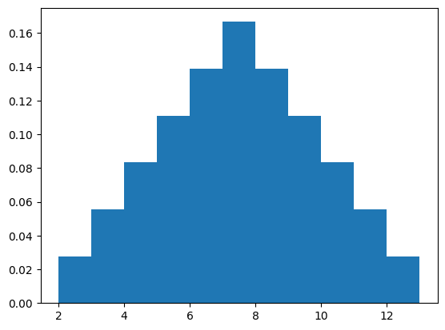

```python
plt.hist(np.array(sum_of_dice),bins=range(2,14), density=True)
plt.plot()
```

# Python Example (simulation)

```python
d1 = np.random.randint(1,7,size=10000)
d2 = np.random.randint(1,7,size=10000)
```

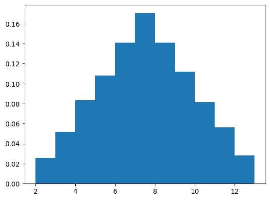

```python
plt.hist(d1 + d2,bins=range(2,14), density=True)
plt.show()
```

```python
sum_to_7_random = [a for a in d1 + d2 if a == 7]

print(f'There are {len(sum_to_7)} ways to roll a sum of 7 on two fair 6-sided dice.')
print(f'The probability of this event is approximately {len(sum_to_7_random)/10000}.')
```

```
There are 6 ways to roll a sum of 7 on two fair 6-sided dice.
The probability of this event is approximately 0.1704.
```